# COMPSCIX 415.2 Homework 7

Chunduri SriKeerthi Chandra

July 24th 2018

### Exercise

#### Load the train.csv dataset into R. How many observations and columns are there?

There are 81 variables and 1,460 observations.

```r
filePath <- "/Users/srchundu/UCBExtension/DataScienceIntro/compscix-415-2-assignments/Lab7/train.csv"
trainData <- read_csv(file = filePath)
```

#### Normally at this point you would spend a few days on EDA, but for this homework we will do some very basic EDA and get right to fitting some linear regression models

Our target will be SalePrice.

- **Visualize the distribution of SalePrice.**

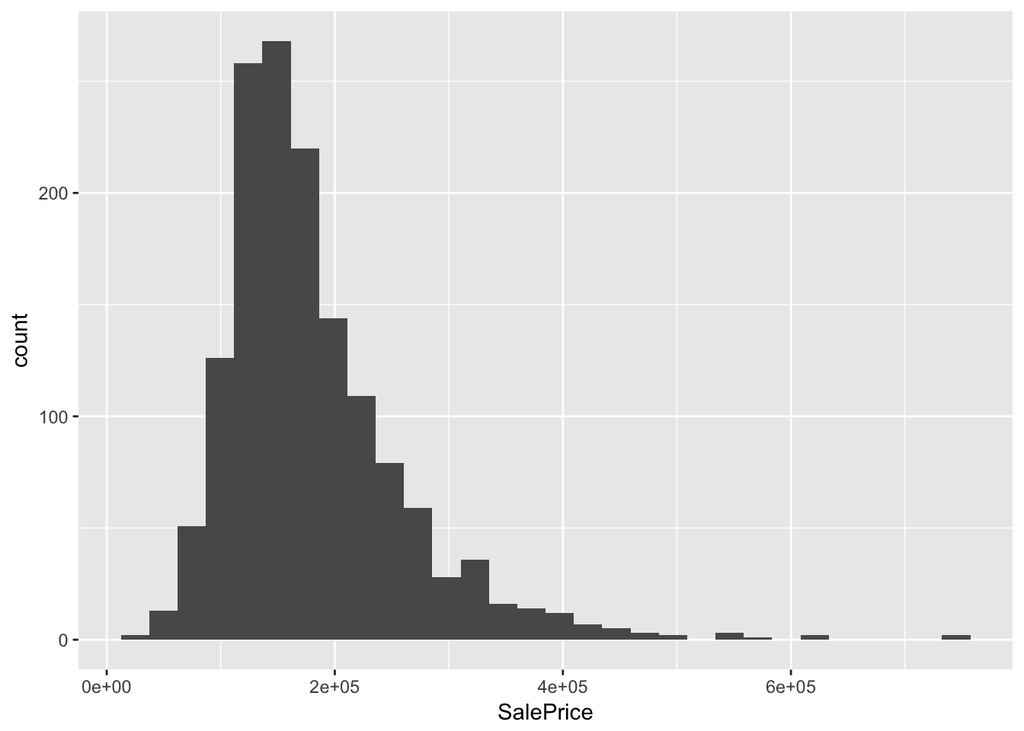

```r
trainData %>% ggplot(mapping = aes(x = SalePrice)) + geom_histogram()
```

- **Visualize the covariation between SalePrice and Neighborhood.**

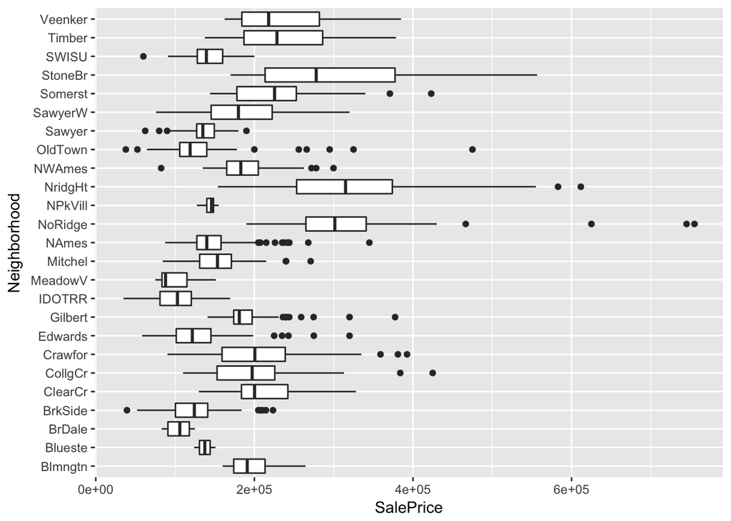

```r
  trainData %>% ggplot(mapping = aes(x = Neighborhood, y = SalePrice)) + geom_boxplot() + coord_flip()
```

- **Visualize the covariation between SalePrice and OverallQual.**

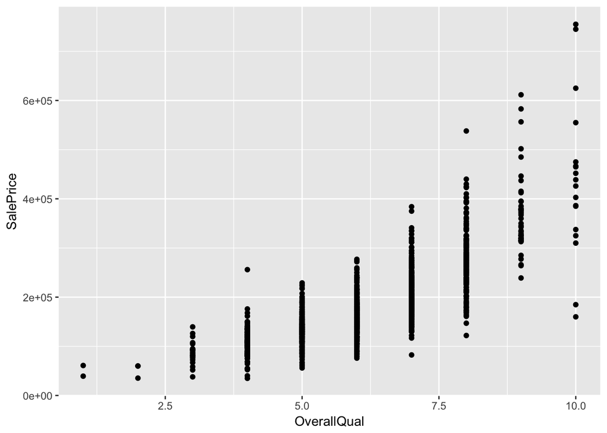

```r
trainData %>% ggplot(mapping = aes(x = OverallQual, y = SalePrice)) + geom_point()
```

** NOTE : ** not answered. Not sure how to define a model which has just the intercept.

#### Now fit a linear regression model using GrLivArea, OverallQual, and Neighborhood as the features. Don’t forget to look at data_description.txt to understand what these variables mean. Ask yourself these questions before fitting the model:

- **What kind of relationship will these features have with our target?** OverallQual and Neighborhood should have a direct impact on the final saleprice. However, GrLiveArea might not be.
- **Can the relationship be estimated linearly?** Yes, we can extablish a linear relationship.
- **Are these good features, given the problem we are trying to solve?** Yes, OverallQual and Neighborhood are good feature. But, GrLivArea might not be.

#### After fitting the model, output the coefficients and the R-squared using the broom package

```r
model <- lm(formula = SalePrice ~ OverallQual + Neighborhood + GrLivArea, data = trainData)
tidy(model)
```

```
##                   term    estimate    std.error   statistic      p.value
## 1          (Intercept) -34829.2399 11541.232315 -3.01780945 2.591005e-03
## 2          OverallQual  20951.4249  1162.273747 18.02623948 1.238994e-65
## 3  NeighborhoodBlueste -30752.8759 27697.270091 -1.11032155 2.670468e-01
## 4   NeighborhoodBrDale -43358.8812 12978.523255 -3.34081778 8.568095e-04
## 5  NeighborhoodBrkSide -13025.4529 10450.444653 -1.24640179 2.128206e-01
## 6  NeighborhoodClearCr  24575.6351 11569.625542  2.12415129 3.382834e-02
## 7  NeighborhoodCollgCr  11414.3095  9496.581581  1.20193876 2.295858e-01
## 8  NeighborhoodCrawfor  14444.2502 10502.214763  1.37535278 1.692371e-01
## 9  NeighborhoodEdwards -17842.9513  9985.733698 -1.78684430 7.417398e-02
## 10 NeighborhoodGilbert   -892.8796  9954.350137 -0.08969743 9.285402e-01
## 11  NeighborhoodIDOTRR -28178.9866 11135.583978 -2.53053514 1.149517e-02
## 12 NeighborhoodMeadowV -19099.0203 12999.351487 -1.46922870 1.419903e-01
## 13 NeighborhoodMitchel   2030.6121 10555.017277  0.19238359 8.474690e-01
## 14   NeighborhoodNAmes  -4430.0994  9517.290569 -0.46547906 6.416592e-01
## 15 NeighborhoodNoRidge  64642.9895 10939.818250  5.90896375 4.294924e-09
## 16 NeighborhoodNPkVill -17807.1837 15304.007123 -1.16356347 2.447947e-01
## 17 NeighborhoodNridgHt  71587.8398  9994.775058  7.16252635 1.262091e-12
## 18  NeighborhoodNWAmes  -4720.6584 10079.514642 -0.46834183 6.396114e-01
## 19 NeighborhoodOldTown -32080.8775  9863.373223 -3.25252596 1.170466e-03
## 20  NeighborhoodSawyer  -1219.3805 10211.495047 -0.11941254 9.049653e-01
## 21 NeighborhoodSawyerW    303.0986 10264.231736  0.02952960 9.764463e-01
## 22 NeighborhoodSomerst  17766.9637  9829.881193  1.80744440 7.090264e-02
## 23 NeighborhoodStoneBr  69954.4718 11689.508047  5.98438117 2.740136e-09
## 24   NeighborhoodSWISU -36640.1517 11923.592410 -3.07291213 2.159781e-03
## 25  NeighborhoodTimber  29905.8114 10829.232809  2.76158172 5.825641e-03
## 26 NeighborhoodVeenker  47106.8929 14337.857486  3.28549039 1.042655e-03
## 27           GrLivArea     55.5645     2.498787 22.23658695 2.375376e-94
```

```r
glance(model)
```

```
##   r.squared adj.r.squared    sigma statistic p.value df    logLik      AIC
## 1 0.7868484      0.782981 37008.52  203.4583       0 27 -17415.62 34887.25
##        BIC     deviance df.residual
## 1 35035.26 1.962681e+12        1433
```

#### One downside of the linear model is that it is sensitive to unusual values because the distance incorporates a squared term. Fit a linear model to the simulated data below (use y as the target and x as the feature), and look at the resulting coefficients and R-squared. Rerun it about 5-6 times to generate different simulated datasets. What do you notice about the model’s coefficient on x and the R-squared values?

```r
sim1a <- tibble(x = rep(1:10, each = 3), y = x * 1.5 + 6 + rt(length(x), df = 2))
model <- lm(formula = y ~ x, data = sim1a)
tidy(model)
```

```
##          term estimate  std.error statistic      p.value
## 1 (Intercept) 5.790215 0.46728821  12.39110 6.964291e-13
## 2           x 1.487013 0.07531031  19.74515 5.677213e-18
```

```r
glance(model)
```

```
##   r.squared adj.r.squared    sigma statistic      p.value df    logLik
## 1 0.9329936     0.9306006 1.184792  389.8708 5.677213e-18  2 -46.62028
##        AIC      BIC deviance df.residual
## 1 99.24055 103.4441 39.30449          28
```